```python
import numpy as np
import galois # https://github.com/mhostetter/galois
```

# MS1 - Algebra - HW3

Михайло Корешков

## Ex 3.1

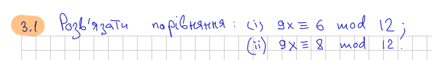

### Ex 3.1.1

$$9x \equiv 6 \mod 12 \quad (1)$$ Спочатку використаємо Приклад 3.8 для кратних коефіцієнтів, бо рівняння можна переписати як $$3\cdot 3 \cdot x \equiv 3 \cdot 2 \mod 3\cdot 4$$ Розглянемо допоміжне рівняння $$3y \equiv 2 \mod 4 \quad (2)$$ Розв'язок рівняння 2 шукаємо за Теоремою 3.5. Умови теореми виконані, оскільки $\gcd(3,4)=1$.
Для розв'язку також знадобиться значення $3^{-1} \mod 4$: $$3\cdot 3 = 9 \equiv 1 \mod 4, \quad \text{отже}\; 3^{-1} = 3$$

$$y = 3^{-1} \cdot 2 \mod 4 = 3 \cdot 2 \mod 4 = 6 \mod 4 = 2$$

Підставимо $y=2$ у (2) і бачимо, що це дійсно розв'язок $$3\cdot 2 = 6 \equiv 2 \mod 4 $$

Розв'язком (1) будуть числа виду $$x_r = 2 + 4r, \; r\in\{0,1,2\}$$ $$x \in \{2, 6, 10\}$$

Перевірка $$18 \mod 12 = 6$$ $$54 \mod 12 = 6$$ $$90 \mod 12 = 6$$

### Ex 3.1.2

$$9x \equiv 8 \mod 12$$ $$3\cdot 3x \equiv 8 \mod 3\cdot 4$$ Розв'язків немає, бо $3\nmid 8$.

## Ex 3.2

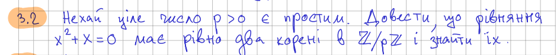

$$x(x+1) = 0$$ Маємо скінченне поле $Z/pZ$ з простим $p$, отже справедлива Властивість 3.2: $$ab=0 \implies a=0 \vee b=0$$ Тому рівняння можна переписати як $$\left[\begin{array}{l} x = 0 \mod p\\ x = p-1 \mod p \end{array} \right.$$

## Ex 3.3

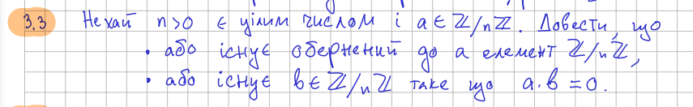

1. Нехай $n=p$ - просте.  
   Тоді за Властивістю 3.3 в $Z/nZ$ існуватиме обернений до $a$ елемент.
2. Нехай $n$ - не просте.  
   Тоді $n = \prod_{p\in\mathcal P} p^{n_p}$.
   1. Припустимо, що $\gcd(a,n) = 1$. Тоді $$\exists x,y\in\mathbb Z: \; ax+ny=1, \; (x\ne 0, y\ne 0)$$ Візьмемо обидві частини р-ня за модулем $n$ $$ax = 1 \mod n$$ Отже, існує обернений елемент.
   2. Інакше $\gcd(a,n) = g$.
      Тоді $a = ug, \; n = vg, \; \gcd(u,v)=1$.
      Зауважу, що $|n|=|v||g|$, тобто $|v|<n$.
      Тоді $$a \cdot v = (ug)v = u(vg) = un = 0 \mod n$$ Тобто знайшли таке $v\in Z/nZ$ що $av = 0 \mod n$

## Ex 3.4

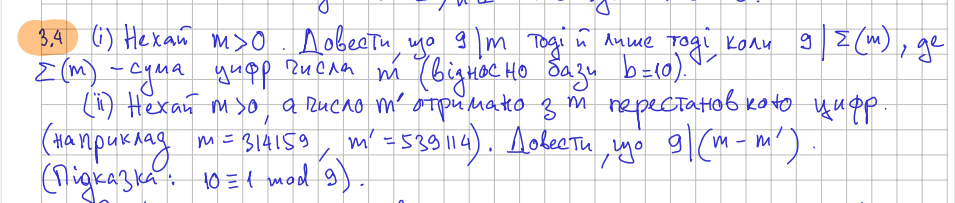

### Ex 3.4.1

$$m = \sum_{k\ge 0} m_k \cdot 10^k$$

$$m = \sum_{k\ge 0} m_k \cdot 10^k \mod 9$$ $$m = \sum_{k\ge 0} m_k \cdot 1^k = \sum_{k\ge 0} m_k\mod 9$$ Тобто $9\mid m \iff m = 0 \mod 9 \iff \sum_{k\ge 0}m_k = 0 \mod 9 \iff 9\mid \sum_{k\ge 0}m_k $

### Ex 3.4.2

$$m = \sum_{k\ge 0} m_k \cdot 10^k$$
$$m' = \sum_{k\ge 0} m_{\pi(k)} \cdot 10^k, \quad \pi \text{ - перестановка}$$

$$(m-m') = \sum_{k\ge 0} (m_k-m_{\pi(k)}) \cdot 10^k = \sum_{k\ge 0} (m_k-m_{\pi(k)}) \cdot 1^k = \sum_{k\ge 0} (m_k-m_{\pi(k)}) = \sum_{k\ge 0} m_k - \sum_{k\ge 0} m_{\pi(k)} = 0\mod 9$$ Тобто $9\mid(m-m')$

## Ex 3.5.1

$$\begin{cases} 3x=2\mod 5\\ 2x=1\mod 3 \end{cases}$$

Щоб застосувати Китайську теорему про лишки потрібно привести систему до канонічного вигляду (з одиничними коефіцієнтами при $x$).

$$3^{-1} \mod 5 = 2$$ $$2^{-1} \mod 3 = 2$$ $$\begin{cases} x=4\mod 5\\ x=2\mod 3 \end{cases}$$

$\gcd(5,3) = 1$.
Застосую китайську теорему про лишки.
$$M_1 = 3, \; M_2 = 5$$ $$s_1 = 3^{-1} \mod 5 = 2$$ $$s_2 = 5^{-1} \mod 3 = 2$$ $$x = 4\cdot 2\cdot 3 + 2\cdot2\cdot5 = 24+20 = 44 = 14 \mod 15 \; (15=3\cdot 5)$$

Перевірка $$42 = 2 \mod 5$$ $$28 = 1 \mod 3$$

## Ex 3.5.2

$$\begin{cases} x=2\mod 5\\ 3x=1\mod 8 \end{cases}$$ $$3^{-1} \mod 8 = 3$$ $$\begin{cases} x=2\mod 5\\ x=3\mod 8 \end{cases}$$

Перевірка $$27 = 2 \mod 5$$ $$81 = 1 \mod 8$$

## Ex 3.6

Представити число 441 в системі числення з базою 13.

```python
N = 441
b = 13
all_digits = '0123456789ABCDEFGHIJKLMNOPQRSTUVWXYZ'

n = N
digits = []
step = 1
while n > 0:
    d = n % b   # modulo
    n = n // b  # integer division
    digits.append(d)
    print(f"step {step}: n={n}, d={d}")
digits.reverse()

print(f"({N})_10 is ({''.join([all_digits[d] for d in digits])})_{b} or {digits}")

m = 0
for k,a_k in enumerate(digits):
    m *= b
    m += a_k
print(f"Checking: {N} == {m}")
```

```
step 1: n=33, d=12
step 1: n=2, d=7
step 1: n=0, d=2
(441)_10 is (27C)_13 or [2, 7, 12]
Checking: 441 == 441
```

Отже, $$441 = 2\cdot13^2 + 7\cdot 13 + 12$$

## Ex 3.7

Обчислити остачу від ділення $10^{100}$ на $7$.

Іншими словами, нас цікавить значення $10^{100} \mod 7$.  
Гарна новина -- 7 це просте число. Значить можемо застосувати Малу Теорему Ферма у вигляді Теореми 3.14.

Спочатку представлю 100 у базі 7: $$100 = 2\cdot 49 + 2 = 2\cdot 7^2 + 2$$ Тоді $$10^{100} = 10^{2+0+2} = 10^4 = 3^4 = 9^2 = 2^2 = 4 \mod 7$$ Додатково я використав той факт, що $$[a]_n[b]_n = [ab]_n$$

```python
print(f"10^4 mod 7 = {10**4 % 7} ")
```

```
10^4 mod 7 = 4
```